# Analysis of NBA Team Twitter Accounts

[figure not shown]

[figure not shown]

[figure not shown]

[figure not shown]

[figure not shown]

[figure not shown]

[figure not shown]

[figure not shown]

### **Temporal Count:** From when did the extracted data come?

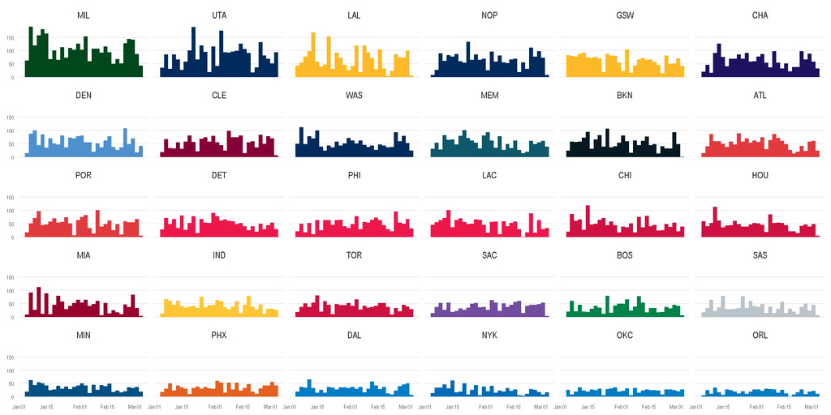

*NOTE:* Only tweets occuring between the last “first” tweet and the first “last” tweet across all entities are shown. In reality, some timelines have tweets going back farther and/or occurring more recently in time. (The actual first tweet occurs at 2017-01-20 17:16:26, and the actual last tweet occurs at 2018-03-04 02:43:57.) Nonetheless, tweets are truncated across entities in order to “normalize” the data.

### **Temporal Count:** Which hours of the day are the most common for each team?

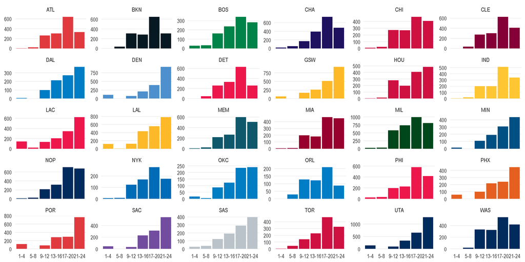

Most activity occurs at the end of the day. This makes sense–nearly all NBA games occur at night.

### **Word (Single) Frequency:** What are the most common words for each team?

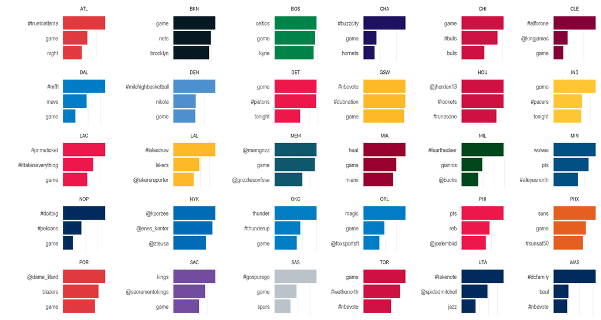

It’s evident that team accounts reference themselves a lot. (After all, these accounts are used primarily for promotional purposes.) Aside from team-level references, the team accounts mention team players a lot, which is not suprising.

### **Word (Single) Frequency:** What are the most common words for each team in the Southwest division?

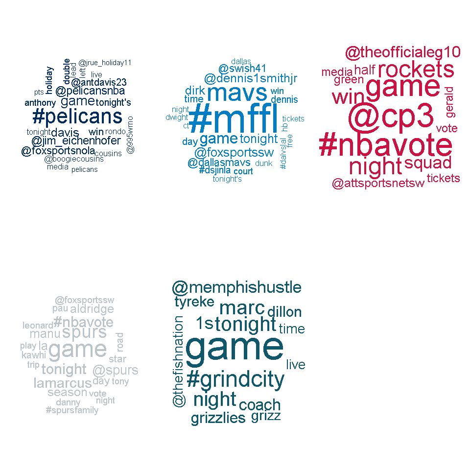

*NOTE:* Due to graphics limitations, only the teams in the Southwest division are shown.

### **Word (Pairs) Frequency:** What are the most common pairs of words for each team?

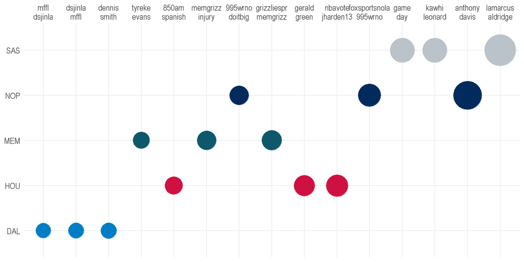

Player names are more prominent here.

### **Word (Single) Frequency:** How different is the vocabulary of each team in the the Southwest division (relative to SAS)?

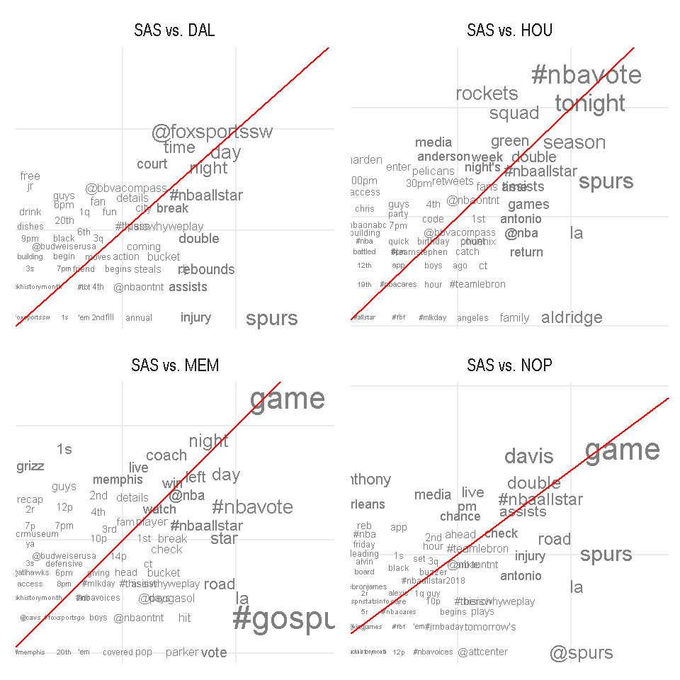

The words diverging most from the splitting line are used much more significantly by one team than the other.

### **Word (Single) Log-Ratio Differences:** What are the most distinct words used by each team in the the Southwest division (relative to SAS)?

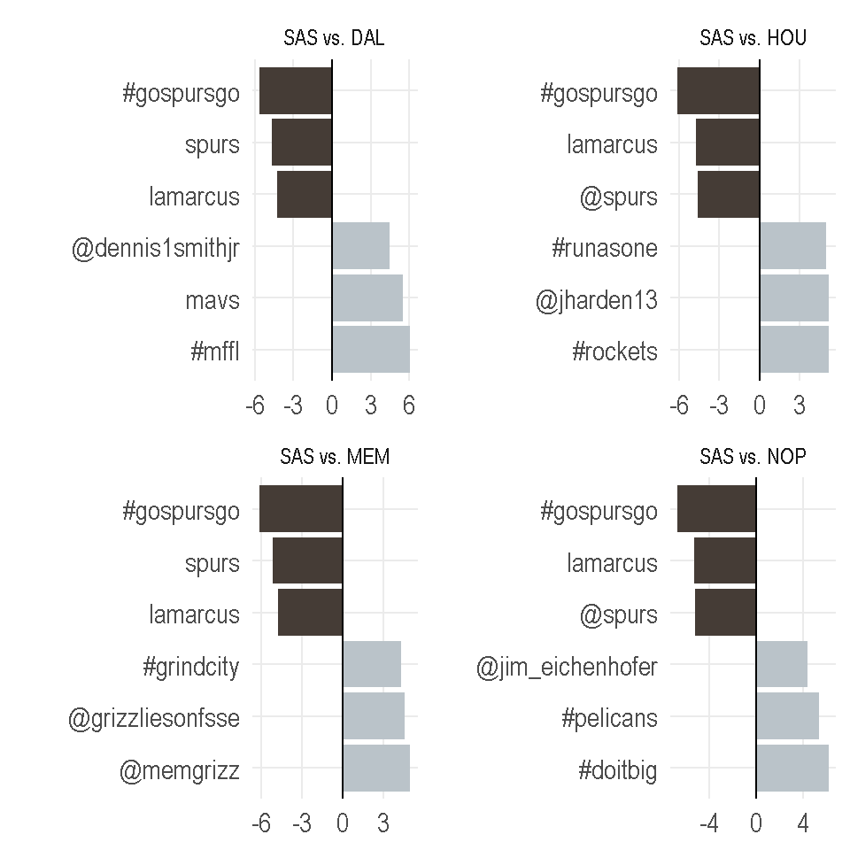

The log-ratio differences of words used by pairs of teams provides a quantitative look at word usage. *NOTE:* The number of words shown for each team and each direction may not be even due to lack of sufficient words meeting the underlying criteria.

### **Word (Single) Sentiment Differences:** How different is each the tone of each team in the the Southwest division (relative to SAS)?

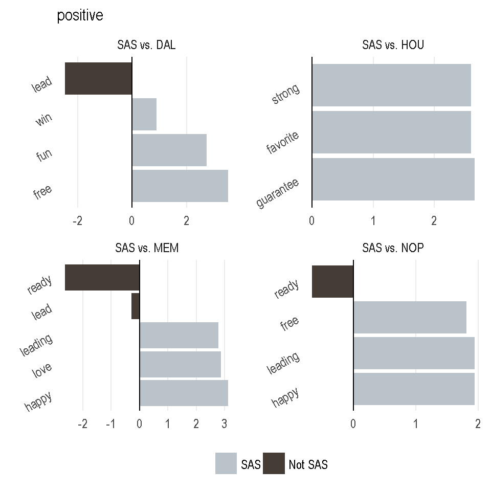

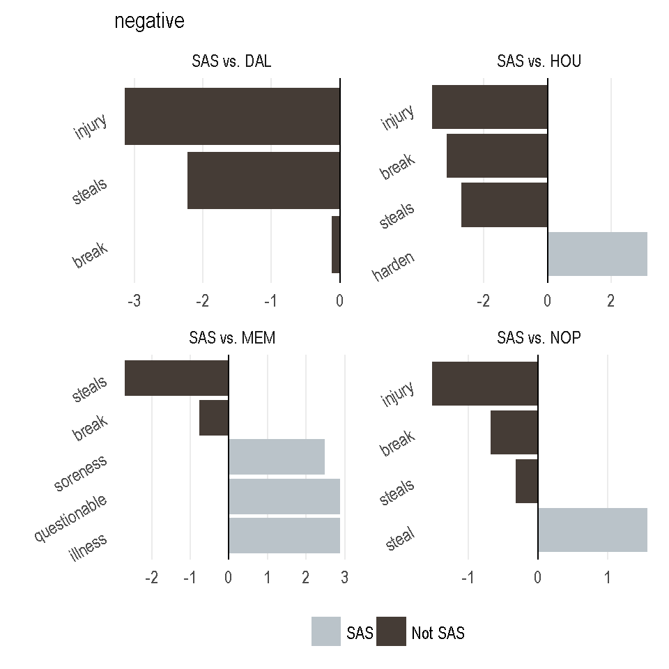

The computations used for identfying strongest sentiment differences is identical to that for log-ratio differences, with an added layer of sentiment “scoring”. *NOTE:* Again, the number of words shown for each pair of teams may not be even.